# **Data Cleaning Pipeline**

### **Initial Raw Data Preparation**

**1. Data Loading and Initial Cleanup**

The initial part of the code pertains to importing the necessary libraries (pandas, numpy, and sklearn) and loading the CSV file.

**2. Handling Outliers and Missing Values (Imputation)**

Identifies unrealistic values and replaces them with a statistical "best guess."

- **Filtering:** It flags "impossible" ages (over 100 or under 0) and negative income as NaN (Not a Number).
- **Imputation:** It replaces those NaN values using the **Median**.

**3. String Standardization**

Real-world data is messy—people type "m", "Male", or "male" for the same thing.

- **Normalization:** The code uses `.str.strip().str.lower()` to remove accidental spaces and make everything lowercase.
- **Mapping:** It uses a dictionary to force all variations of gender into two clean categories: Male and Female.
- **Capitalization:** It ensures *Device_Type* looks consistent (e.g., "Mobile", "Desktop").

**4. Feature Engineering: Binning and Merging**

This section creates new data from existing info.

- **pd.cut (Binning):** It turns a continuous number (Items_Purchased) into a categorical group (Low, Medium, High). This helps models focus on levels of activity.
- **pd.merge:** This mimics a SQL "JOIN." It pulls tax rate information from a separate small table and attaches it based on their Store_Region.

**5. Feature Scaling (Normalization)**

This is the most critical step for models like KNN.

- **MinMaxScaler:** It shrinks all numeric values (Age, Income, etc.) to a range between 0 and 1.
- **The Math:** It uses the formula:

$$x_{scaled} = \frac{x - x_{min}}{x_{max} - x_{min}}$$

**Pro Tip:** KNN calculates the distance between points. Scaling puts features on an equal playing field so "Income" doesn't drown out "Support Calls."

**6. Categorical Encoding**

Machine learning models speak the language of numbers, not words.

- **pd.get_dummies (One-Hot Encoding):** This turns categorical columns into multiple columns of 1s and 0s.
- **Example:** A "Region" column with "North" and "South" becomes two columns: `Region_North` and `Region_South`.

**7. Final Cleanup and Export**

Finally, the script removes columns that aren't useful for a mathematical model (like IDs and Dates) and saves the result to a new file, `cleaned_knn_data.csv`.

##### **Code:**

```python
import pandas as pd  # Import the pandas library for data manipulation and analysis
import numpy as np  # Import the numpy library for numerical operations and handling NaN values
from sklearn.preprocessing import MinMaxScaler  # Import the MinMaxScaler to normalize numeric features to a 0-1 range

# Load the dataset from the specified CSV file into a pandas DataFrame
df = pd.read_csv('/content/adjusted_noisy_knn_300.csv')

# Remove duplicate rows based specifically on the 'Customer_ID' column to ensure unique customers
df = df.drop_duplicates(subset=['Customer_ID'])

# Replace 'Age' values that are greater than 100 or less than 0 with NaN (Not a Number) to handle outliers
df.loc[(df['Age'] > 100) | (df['Age'] < 0), 'Age'] = np.nan

# Replace 'Annual_Income' values that are negative with NaN to handle data entry errors
df.loc[df['Annual_Income'] < 0, 'Annual_Income'] = np.nan

# Fill missing 'Age' values with the median age (median is used to avoid skew from outliers)
df['Age'] = df['Age'].fillna(df['Age'].median())

# Fill missing 'Annual_Income' values with the median income
df['Annual_Income'] = df['Annual_Income'].fillna(df['Annual_Income'].median())

# Fill missing 'Total_Spend' values with the median spend amount
df['Total_Spend'] = df['Total_Spend'].fillna(df['Total_Spend'].median())

# Standardize the 'Gender' column: strip whitespace, convert to lowercase, and map variations (e.g., 'm', 'fem') to standard 'Male'/'Female'
df['Gender'] = df['Gender'].str.strip().str.lower().replace({
    'm': 'Male', 'male': 'Male', 'f': 'Female', 'female': 'Female', 'fem': 'Female'
})

# Standardize the 'Device_Type' column: strip whitespace and capitalize the first letter (e.g., "mobile" -> "Mobile")
df['Device_Type'] = df['Device_Type'].str.strip().str.capitalize()

# Create a new categorical column 'Purchase_Volume' by binning 'Items_Purchased' into specific ranges (Low, Medium, High)
df['Purchase_Volume'] = pd.cut(df['Items_Purchased'],
                               bins=[0, 15, 35, 51],  # Define the edges of the bins
                               labels=['Low', 'Medium', 'High'])  # Define the labels for the bins

# Create a temporary DataFrame to map tax rates to specific geographic regions
region_tax_data = pd.DataFrame({
    'Store_Region': ['North', 'South', 'East', 'West'],
    'Tax_Rate': [0.05, 0.07, 0.06, 0.08]
})

# Merge the original DataFrame with the tax data (left join) to add the 'Tax_Rate' column based on 'Store_Region'
df = pd.merge(df, region_tax_data, on='Store_Region', how='left')

# Initialize the MinMaxScaler object to scale data between 0 and 1
scaler = MinMaxScaler()

# Define the list of numerical columns that need to be scaled
numeric_cols = ['Age', 'Annual_Income', 'Total_Spend', 'Items_Purchased',
                'Last_Logon_Days', 'Support_Calls', 'Tax_Rate']

# Fit the scaler to the data (calculate min/max) and transform the data (apply the formula) for the selected columns
df[numeric_cols] = scaler.fit_transform(df[numeric_cols])

# Convert categorical variables (Gender, Device, Region, Purchase_Volume) into dummy/indicator variables (One-Hot Encoding)
df = pd.get_dummies(df, columns=['Gender', 'Device_Type', 'Store_Region', 'Purchase_Volume'])

# Define a list of columns that are no longer needed for the machine learning model
cols_to_drop = ['Membership_Score', 'Newsletter_Sub', 'Customer_ID', 'Purchase_Date']

# Drop the specified columns to create the final processed DataFrame
df_final = df.drop(columns=cols_to_drop)

# Save the final cleaned and processed dataset to a new CSV file, excluding the index numbers
df_final.to_csv('cleaned_knn_data.csv', index=False)

# Print a confirmation message along with the shape (rows, columns) of the final dataset
print("Data Preparation Complete. Final shape:", df_final.shape)
```

```
Data Preparation Complete. Final shape: (286, 21)
```

# **Challenge: Data Preparation Optimization**

# Data Preprocessing Explanation

## **1. Data Cleaning (Standardization)**

The code first addresses "dirty" text data. Categorical data often has inconsistencies like trailing spaces (`"North "`) or mixed capitalization (`"male"` vs `"Male"`).

- **`.strip()`**: Removes accidental whitespace.
- **`.lower()/.title()`**: Ensures "South", "south", and "SOUTH" are all treated as the same entity.
- **`.replace()`**: Maps multiple shorthand versions (m, f, fem) to standard labels.

## **2. Handling Outliers (The Strict Approach)**

Instead of trying to "fix" impossible data points (like a 200-year-old customer), the script **filters them out**.

- **Logic**: If a row has an impossible age or negative income, the rest of the data in that row is likely corrupted or "garbage." Removing them ensures the model isn't trained on hallucinations.

## **3. Handling Missing Values (Imputation)**

For rows that are mostly good but missing a single value, the script fills the gaps:

- **Median**: Used for numbers (Age, Income) because it is resistant to outliers.
- **Mode**: Used for categorical data (Region) to fill the gap with the most common occurrence.

## **4. Feature Engineering**

This section creates new value from existing data:

- **Binning**: It converts the raw number of `Items_Purchased` into categories (**Low, Medium, High**). This helps models see patterns rather than getting lost in small numerical differences.
- **Data Merging**: It maps a specific `Tax_Rate` to each `Store_Region`. This adds economic context that wasn't in the original dataset.

## **5. Feature Selection**

In data science, **less is often more**.

- The script drops columns like `Customer_ID` (which is just a random label) and `Support_Calls` (which the comments suggest had no statistical relationship to the goal).
- Removing **"Noise"** prevents the model from finding patterns where none exist (overfitting).

## **6. Scaling & Encoding**

This is the most critical step for algorithms like **KNN**, which calculate "distance" between points.

- **MinMaxScaler**: This squashes all numbers into a range between **0 and 1**.
  - **Why?** If Age is 20 and Income is 50,000, a model would think Income is "more important" just because the number is bigger. Scaling makes them equal.
- **One-Hot Encoding (`get_dummies`)**: Computers can't "read" the word "Male" or "Female." This converts categories into binary columns ($0$ or $1$).

```python
import pandas as pd
import numpy as np
from sklearn.preprocessing import MinMaxScaler

# --- LOAD DATA ---
df = pd.read_csv('/content/adjusted_noisy_knn_300.csv')

# --- 1. CLEANING TEXT (Standardization) ---
# Fix Gender
df['Gender'] = df['Gender'].str.strip().str.lower().replace({
    'm': 'Male', 'male': 'Male', 'f': 'Female', 'female': 'Female', 'fem': 'Female'
})
# Fix Device
df['Device_Type'] = df['Device_Type'].str.strip().str.capitalize()
# Fix Region (CRITICAL: removes the space in "South " that broke the tax merge)
df['Store_Region'] = df['Store_Region'].str.strip().str.title()

# --- 2. HANDLING OUTLIERS (The Strict Approach) ---
# Instead of guessing values for Age 200 or -10, we DROP the rows.
# Bad data in one column often means the whole row is unreliable.
df = df[df['Age'] <= 100]  # Drop Age 200
df = df[df['Age'] > 0]     # Drop Age -10
df = df[df['Annual_Income'] > 0] # Drop negative income

# --- 3. HANDLING MISSING VALUES ---
# For the remaining small gaps, we use Median
cols_to_impute = ['Age', 'Annual_Income', 'Membership_Score']
for col in cols_to_impute:
    df[col] = df[col].fillna(df[col].median())

# Fill missing Region with Mode
df['Store_Region'] = df['Store_Region'].fillna(df['Store_Region'].mode()[0])

# --- 4. FEATURE ENGINEERING ---
# Ensure that Bins are enqually distributed [0, 17, 34, 51] from [0, 15, 35, 51]
df['Purchase_Volume'] = pd.cut(df['Items_Purchased'],
                               bins=[0, 17, 34, 51],
                               labels=['Low', 'Medium', 'High'])

# Add Tax Rates (Now works perfectly because Region is fixed)
region_tax_data = pd.DataFrame({
    'Store_Region': ['North', 'South', 'East', 'West'],
    'Tax_Rate': [0.05, 0.07, 0.06, 0.08]
})
df = pd.merge(df, region_tax_data, on='Store_Region', how='left')
df['Tax_Rate'] = df['Tax_Rate'].fillna(df['Tax_Rate'].median())

# Convert Promo_User to number
df['Promo_User'] = df['Promo_User'].astype(int)

# --- 5. FEATURE SELECTION (Removing Noise) ---
# DROP 'Total_Spend' and 'Support_Calls' because they had
# very low correlation with Purchase_Likelihood. They are just noise.
cols_to_drop = ['Newsletter_Sub', 'Customer_ID', 'Purchase_Date', 'Total_Spend', 'Support_Calls']
df_final = df.drop(columns=cols_to_drop)

# --- 6. SCALING & ENCODING ---
scaler = MinMaxScaler()
# Scale only the remaining numeric columns
numeric_cols = ['Age', 'Annual_Income', 'Items_Purchased',
                'Last_Logon_Days', 'Tax_Rate', 'Membership_Score', 'Promo_User']
df_final[numeric_cols] = scaler.fit_transform(df_final[numeric_cols])

# One-Hot Encoding
df_final = pd.get_dummies(df_final, columns=['Gender', 'Device_Type', 'Store_Region', 'Purchase_Volume'])

# Save
df_final.to_csv('cleaned_knn_data_strict.csv', index=False)
print("Strict Cleaning Complete. Final shape:", df_final.shape)
```

```
Strict Cleaning Complete. Final shape: (66, 20)
```

# **Implementing kNN with raw dataset**

**1. Rapid Data Loading and Numerical Selection**

The process begins with the script importing necessary libraries and loading the raw dataset from a CSV file into a pandas DataFrame.

- **select_dtypes:** The script automatically filters the dataset to retain only integer and float columns, which serves to eliminate non-numeric "noise" such as Names or IDs.
- **Feature Preservation:** This step ensures that only variables capable of being processed by a mathematical model are passed into the next stage.

**2. Aggressive Data Cleaning (Listwise Deletion)**

The script prioritizes data integrity by ensuring the algorithm only learns from complete records without utilizing statistical "best guesses."

- **dropna():** By removing any row containing at least one missing value (NaN), the script guarantees that the KNN algorithm will not encounter errors during its distance calculations.
- **Effect on Volume:** While this approach may reduce the total number of samples, it ensures that every data point used for training is verified and accurate.

**3. Feature-Target Separation**

The script defines the mathematical mapping for the model by separating the outcome variable from the input data.

- **Target Variable (y):** The script isolates `Purchase_Likelihood` as the specific value the model is intended to predict.
- **Features (X):** The remaining numerical columns are set as the inputs, providing the raw data from which the model will identify patterns.

**4. Dataset Splitting (Train/Test Theory)**

To evaluate how the model functions on data it has not previously encountered, a standard validation strategy is implemented.

- **train_test_split:** The script reserves 20% of the data for testing, while the remaining 80% is used for the training phase.
- **Overfitting Prevention:** This split is used to verify that the model is learning general patterns rather than simply memorizing the training dataset.

**5. Model Selection: The K-Nearest Neighbors (KNN)**

The script employs the KNN algorithm, a distance-based method that categorizes data points based on their proximity to historical neighbors.

##### **Code: k value = 1**

```python
import pandas as pd
from sklearn.model_selection import train_test_split
from sklearn.neighbors import KNeighborsClassifier
from sklearn.metrics import accuracy_score, confusion_matrix

# Load the adjusted dataset
df_raw = pd.read_csv('/content/adjusted_noisy_knn_300.csv')

# --- Baseline Preparation ---
# 1. Keep only numeric columns (this automatically drops string 'noise')
# 2. Drop rows with any remaining NaN values
df_naive = df_raw.select_dtypes(include=['number']).dropna()

# Separate Features (X) and Target (y)
X_naive = df_naive.drop(columns=['Purchase_Likelihood'])
y_naive = df_naive['Purchase_Likelihood']

# Split the data
X_train, X_test, y_train, y_test = train_test_split(X_naive, y_naive, test_size=0.2, random_state=42)

# Train k-NN (k=1)
knn_naive = KNeighborsClassifier(n_neighbors=1)
knn_naive.fit(X_train, y_train)

# Evaluate
y_pred = knn_naive.predict(X_test)
print(f"Baseline Accuracy: {accuracy_score(y_test, y_pred):.2%}")
print("Baseline Confusion Matrix:\n", confusion_matrix(y_test, y_pred))
```

```
Baseline Accuracy: 50.00%
Baseline Confusion Matrix:
 [[2 2]
 [5 5]]
```

##### **Code: k value = 3**

```python
import pandas as pd
from sklearn.model_selection import train_test_split
from sklearn.neighbors import KNeighborsClassifier
from sklearn.metrics import accuracy_score, confusion_matrix

# Load the adjusted dataset
df_raw = pd.read_csv('/content/adjusted_noisy_knn_300.csv')

# --- Baseline Preparation ---
# 1. Keep only numeric columns (this automatically drops string 'noise')
# 2. Drop rows with any remaining NaN values
df_naive = df_raw.select_dtypes(include=['number']).dropna()

# Separate Features (X) and Target (y)
X_naive = df_naive.drop(columns=['Purchase_Likelihood'])
y_naive = df_naive['Purchase_Likelihood']

# Split the data
X_train, X_test, y_train, y_test = train_test_split(X_naive, y_naive, test_size=0.2, random_state=42)

# Train k-NN (k=3)
knn_naive = KNeighborsClassifier(n_neighbors=3)
knn_naive.fit(X_train, y_train)

# Evaluate
y_pred = knn_naive.predict(X_test)
print(f"Baseline Accuracy: {accuracy_score(y_test, y_pred):.2%}")
print("Baseline Confusion Matrix:\n", confusion_matrix(y_test, y_pred))
```

```
Baseline Accuracy: 64.29%
Baseline Confusion Matrix:
 [[3 1]
 [4 6]]
```

##### **Code: k value = 5**

```python
import pandas as pd
from sklearn.model_selection import train_test_split
from sklearn.neighbors import KNeighborsClassifier
from sklearn.metrics import accuracy_score, confusion_matrix

# Load the adjusted dataset
df_raw = pd.read_csv('/content/adjusted_noisy_knn_300.csv')

# --- Baseline Preparation ---
# 1. Keep only numeric columns (this automatically drops string 'noise')
# 2. Drop rows with any remaining NaN values
df_naive = df_raw.select_dtypes(include=['number']).dropna()

# Separate Features (X) and Target (y)
X_naive = df_naive.drop(columns=['Purchase_Likelihood'])
y_naive = df_naive['Purchase_Likelihood']

# Split the data
X_train, X_test, y_train, y_test = train_test_split(X_naive, y_naive, test_size=0.2, random_state=42)

# Train k-NN (k=5)
knn_naive = KNeighborsClassifier(n_neighbors=5)
knn_naive.fit(X_train, y_train)

# Evaluate
y_pred = knn_naive.predict(X_test)
print(f"Baseline Accuracy: {accuracy_score(y_test, y_pred):.2%}")
print("Baseline Confusion Matrix:\n", confusion_matrix(y_test, y_pred))
```

```
Baseline Accuracy: 42.86%
Baseline Confusion Matrix:
 [[3 1]
 [7 3]]
```

##### **Code: k value = 7**

```python
import pandas as pd
from sklearn.model_selection import train_test_split
from sklearn.neighbors import KNeighborsClassifier
from sklearn.metrics import accuracy_score, confusion_matrix

# Load the adjusted dataset
df_raw = pd.read_csv('/content/adjusted_noisy_knn_300.csv')

# --- Baseline Preparation ---
# 1. Keep only numeric columns (this automatically drops string 'noise')
# 2. Drop rows with any remaining NaN values
df_naive = df_raw.select_dtypes(include=['number']).dropna()

# Separate Features (X) and Target (y)
X_naive = df_naive.drop(columns=['Purchase_Likelihood'])
y_naive = df_naive['Purchase_Likelihood']

# Split the data
X_train, X_test, y_train, y_test = train_test_split(X_naive, y_naive, test_size=0.2, random_state=42)

# Train k-NN (k=7)
knn_naive = KNeighborsClassifier(n_neighbors=7)
knn_naive.fit(X_train, y_train)

# Evaluate
y_pred = knn_naive.predict(X_test)
print(f"Baseline Accuracy: {accuracy_score(y_test, y_pred):.2%}")
print("Baseline Confusion Matrix:\n", confusion_matrix(y_test, y_pred))
```

```
Baseline Accuracy: 57.14%
Baseline Confusion Matrix:
 [[3 1]
 [5 5]]
```

##### **Code: k value = 11**

```python
import pandas as pd
from sklearn.model_selection import train_test_split
from sklearn.neighbors import KNeighborsClassifier
from sklearn.metrics import accuracy_score, confusion_matrix

# Load the adjusted dataset
df_raw = pd.read_csv('/content/adjusted_noisy_knn_300.csv')

# --- Baseline Preparation ---
# 1. Keep only numeric columns (this automatically drops string 'noise')
# 2. Drop rows with any remaining NaN values
df_naive = df_raw.select_dtypes(include=['number']).dropna()

# Separate Features (X) and Target (y)
X_naive = df_naive.drop(columns=['Purchase_Likelihood'])
y_naive = df_naive['Purchase_Likelihood']

# Split the data
X_train, X_test, y_train, y_test = train_test_split(X_naive, y_naive, test_size=0.2, random_state=42)

# Train k-NN (k=11)
knn_naive = KNeighborsClassifier(n_neighbors=11)
knn_naive.fit(X_train, y_train)

# Evaluate
y_pred = knn_naive.predict(X_test)
print(f"Baseline Accuracy: {accuracy_score(y_test, y_pred):.2%}")
print("Baseline Confusion Matrix:\n", confusion_matrix(y_test, y_pred))
```

```
Baseline Accuracy: 57.14%
Baseline Confusion Matrix:
 [[3 1]
 [5 5]]
```

##### **Code: k value = 13**

```python
import pandas as pd
from sklearn.model_selection import train_test_split
from sklearn.neighbors import KNeighborsClassifier
from sklearn.metrics import accuracy_score, confusion_matrix

# Load the adjusted dataset
df_raw = pd.read_csv('/content/adjusted_noisy_knn_300.csv')

# --- Baseline Preparation ---
# 1. Keep only numeric columns (this automatically drops string 'noise')
# 2. Drop rows with any remaining NaN values
df_naive = df_raw.select_dtypes(include=['number']).dropna()

# Separate Features (X) and Target (y)
X_naive = df_naive.drop(columns=['Purchase_Likelihood'])
y_naive = df_naive['Purchase_Likelihood']

# Split the data
X_train, X_test, y_train, y_test = train_test_split(X_naive, y_naive, test_size=0.2, random_state=42)

# Train k-NN (k=13)
knn_naive = KNeighborsClassifier(n_neighbors=13)
knn_naive.fit(X_train, y_train)

# Evaluate
y_pred = knn_naive.predict(X_test)
print(f"Baseline Accuracy: {accuracy_score(y_test, y_pred):.2%}")
print("Baseline Confusion Matrix:\n", confusion_matrix(y_test, y_pred))
```

```
Baseline Accuracy: 57.14%
Baseline Confusion Matrix:
 [[3 1]
 [5 5]]
```

##### **Code: k value = 15**

```python
import pandas as pd
from sklearn.model_selection import train_test_split
from sklearn.neighbors import KNeighborsClassifier
from sklearn.metrics import accuracy_score, confusion_matrix

# Load the adjusted dataset
df_raw = pd.read_csv('/content/adjusted_noisy_knn_300.csv')

# --- Baseline Preparation ---
# 1. Keep only numeric columns (this automatically drops string 'noise')
# 2. Drop rows with any remaining NaN values
df_naive = df_raw.select_dtypes(include=['number']).dropna()

# Separate Features (X) and Target (y)
X_naive = df_naive.drop(columns=['Purchase_Likelihood'])
y_naive = df_naive['Purchase_Likelihood']

# Split the data
X_train, X_test, y_train, y_test = train_test_split(X_naive, y_naive, test_size=0.2, random_state=42)

# Train k-NN (k=15)
knn_naive = KNeighborsClassifier(n_neighbors=15)
knn_naive.fit(X_train, y_train)

# Evaluate
y_pred = knn_naive.predict(X_test)
print(f"Baseline Accuracy: {accuracy_score(y_test, y_pred):.2%}")
print("Baseline Confusion Matrix:\n", confusion_matrix(y_test, y_pred))
```

```
Baseline Accuracy: 57.14%
Baseline Confusion Matrix:
 [[3 1]
 [5 5]]
```

##### **Code: k value = 17**

```python
import pandas as pd
from sklearn.model_selection import train_test_split
from sklearn.neighbors import KNeighborsClassifier
from sklearn.metrics import accuracy_score, confusion_matrix

# Load the adjusted dataset
df_raw = pd.read_csv('/content/adjusted_noisy_knn_300.csv')

# --- Baseline Preparation ---
# 1. Keep only numeric columns (this automatically drops string 'noise')
# 2. Drop rows with any remaining NaN values
df_naive = df_raw.select_dtypes(include=['number']).dropna()

# Separate Features (X) and Target (y)
X_naive = df_naive.drop(columns=['Purchase_Likelihood'])
y_naive = df_naive['Purchase_Likelihood']

# Split the data
X_train, X_test, y_train, y_test = train_test_split(X_naive, y_naive, test_size=0.2, random_state=42)

# Train k-NN (k=17)
knn_naive = KNeighborsClassifier(n_neighbors=17)
knn_naive.fit(X_train, y_train)

# Evaluate
y_pred = knn_naive.predict(X_test)
print(f"Baseline Accuracy: {accuracy_score(y_test, y_pred):.2%}")
print("Baseline Confusion Matrix:\n", confusion_matrix(y_test, y_pred))
```

```
Baseline Accuracy: 57.14%
Baseline Confusion Matrix:
 [[3 1]
 [5 5]]
```

##### **Code: k value = 19**

```python
import pandas as pd
from sklearn.model_selection import train_test_split
from sklearn.neighbors import KNeighborsClassifier
from sklearn.metrics import accuracy_score, confusion_matrix

# Load the adjusted dataset
df_raw = pd.read_csv('/content/adjusted_noisy_knn_300.csv')

# --- Baseline Preparation ---
# 1. Keep only numeric columns (this automatically drops string 'noise')
# 2. Drop rows with any remaining NaN values
df_naive = df_raw.select_dtypes(include=['number']).dropna()

# Separate Features (X) and Target (y)
X_naive = df_naive.drop(columns=['Purchase_Likelihood'])
y_naive = df_naive['Purchase_Likelihood']

# Split the data
X_train, X_test, y_train, y_test = train_test_split(X_naive, y_naive, test_size=0.2, random_state=42)

# Train k-NN (k=19)
knn_naive = KNeighborsClassifier(n_neighbors=19)
knn_naive.fit(X_train, y_train)

# Evaluate
y_pred = knn_naive.predict(X_test)
print(f"Baseline Accuracy: {accuracy_score(y_test, y_pred):.2%}")
print("Baseline Confusion Matrix:\n", confusion_matrix(y_test, y_pred))
```

```
Baseline Accuracy: 57.14%
Baseline Confusion Matrix:
 [[3 1]
 [5 5]]
```

# **Implementing kNN with prepared dataset**

**1. Rapid Data Loading and Numerical Selection**

The script begins by prioritizing speed and core numerical relationships by focusing exclusively on data types that the machine understands natively.

**3. Feature-Target Separation**

To prepare for training, the code explicitly defines what the model is attempting to predict versus what it is using as a reference for learning.

- **X & y Split:** The script isolates `Purchase_Likelihood` as the target variable ($y$).
- **Features:** It utilizes the remaining numerical columns as features ($X$) to create a clear mathematical mapping for the algorithm.

**4. Dataset Splitting (Train/Test Theory)**

To ensure the model functions on data it has not previously encountered, a standard validation strategy is implemented.

- **train_test_split:** The code reserves 20% of the data for testing.
- **Overfitting Prevention:** This step ensures the accuracy score reflects actual learning rather than the model simply "memorizing" the training set.

**5. Model Selection: The K-Nearest Neighbors (KNN)**

The script employs KNN because it is an intuitive, distance-based algorithm that categorizes data points based on their proximity to others.

- **K-Neighbors:** By setting `n_neighbors= 1, 3, 5, 7, 9, 11, 13, 15, 17, and 19`, the model examines the 1, 3, 5, 7, 9, 11, 13, 15, 17, and 19 most similar historical customers to predict the behavior of a new customer.
- **The Math:** Similarity is calculated using the Euclidean distance formula:

$$d(p, q) = \sqrt{\sum_{i=1}^{n} (p_i - q_i)^2}$$

**6. Baseline Performance Metrics**

- **Accuracy Score:** This provides a percentage representing how many purchases were predicted correctly.
- **Confusion Matrix:** This tool breaks down errors, showing exactly where the model is getting confused (e.g., predicting a "Purchase" when a customer actually "Left").

##### **Code: k value = 1**

```python
import pandas as pd
import matplotlib.pyplot as plt
import seaborn as sns
from sklearn.model_selection import train_test_split
from sklearn.neighbors import KNeighborsClassifier
from sklearn.metrics import accuracy_score, confusion_matrix, classification_report

# 1. Load the prepared dataset
df_prepared = pd.read_csv('/content/cleaned_knn_data.csv')

# --- SAFETY CHECK: HANDLE REMAINING NaNs ---
if df_prepared.isnull().values.any():
    print(f"Detecting {df_prepared.isnull().sum().sum()} missing values...")
    # Fill with median to keep data integrity
    df_prepared = df_prepared.fillna(df_prepared.median(numeric_only=True))
    print("Missing values handled.")

# 2. Separate Features (X) and Target (y)
target_col = 'Purchase_Likelihood'
X = df_prepared.drop(columns=[target_col])
y = df_prepared[target_col]

# 3. Split the Data (80% Training, 20% Testing)
X_train, X_test, y_train, y_test = train_test_split(X, y, test_size=0.2, random_state=42)

# 4. Train the k-NN Model (Optimized Run with k=1)
knn = KNeighborsClassifier(n_neighbors=1)
knn.fit(X_train, y_train)

# 5. Evaluate the Model
y_pred = knn.predict(X_test)

print("\n--- Optimized k-NN Model Results ---")
print(f"Accuracy Score: {accuracy_score(y_test, y_pred):.2%}")
print("\nConfusion Matrix:")
print(confusion_matrix(y_test, y_pred))
print("\nClassification Report:")
print(classification_report(y_test, y_pred))
```

```
Detecting 159 missing values...
Missing values handled.

--- Optimized k-NN Model Results ---
Accuracy Score: 67.24%

Confusion Matrix:
[[21 10]
 [ 9 18]]

Classification Report:
              precision    recall  f1-score   support

           0       0.70      0.68      0.69        31
           1       0.64      0.67      0.65        27

    accuracy                           0.67        58
   macro avg       0.67      0.67      0.67        58
weighted avg       0.67      0.67      0.67        58
```

##### **Code: k value = 3**

```python
import pandas as pd
import matplotlib.pyplot as plt
import seaborn as sns
from sklearn.model_selection import train_test_split
from sklearn.neighbors import KNeighborsClassifier
from sklearn.metrics import accuracy_score, confusion_matrix, classification_report

# 1. Load the prepared dataset
df_prepared = pd.read_csv('/content/cleaned_knn_data.csv')

# --- SAFETY CHECK: HANDLE REMAINING NaNs ---
if df_prepared.isnull().values.any():
    print(f"Detecting {df_prepared.isnull().sum().sum()} missing values...")
    # Fill with median to keep data integrity
    df_prepared = df_prepared.fillna(df_prepared.median(numeric_only=True))
    print("Missing values handled.")

# 2. Separate Features (X) and Target (y)
target_col = 'Purchase_Likelihood'
X = df_prepared.drop(columns=[target_col])
y = df_prepared[target_col]

# 3. Split the Data (80% Training, 20% Testing)
X_train, X_test, y_train, y_test = train_test_split(X, y, test_size=0.2, random_state=42)

# 4. Train the k-NN Model (Optimized Run with k=3)
knn = KNeighborsClassifier(n_neighbors=3)
knn.fit(X_train, y_train)

# 5. Evaluate the Model
y_pred = knn.predict(X_test)

print("\n--- Optimized k-NN Model Results ---")
print(f"Accuracy Score: {accuracy_score(y_test, y_pred):.2%}")
print("\nConfusion Matrix:")
print(confusion_matrix(y_test, y_pred))
print("\nClassification Report:")
print(classification_report(y_test, y_pred))
```

```
Detecting 159 missing values...
Missing values handled.

--- Optimized k-NN Model Results ---
Accuracy Score: 72.41%

Confusion Matrix:
[[21 10]
 [ 6 21]]

Classification Report:
              precision    recall  f1-score   support

           0       0.78      0.68      0.72        31
           1       0.68      0.78      0.72        27

    accuracy                           0.72        58
   macro avg       0.73      0.73      0.72        58
weighted avg       0.73      0.72      0.72        58
```

##### **Code: k value = 5**

```python
import pandas as pd
import matplotlib.pyplot as plt
import seaborn as sns
from sklearn.model_selection import train_test_split
from sklearn.neighbors import KNeighborsClassifier
from sklearn.metrics import accuracy_score, confusion_matrix, classification_report

# 1. Load the prepared dataset
df_prepared = pd.read_csv('/content/cleaned_knn_data.csv')

# --- SAFETY CHECK: HANDLE REMAINING NaNs ---
if df_prepared.isnull().values.any():
    print(f"Detecting {df_prepared.isnull().sum().sum()} missing values...")
    # Fill with median to keep data integrity
    df_prepared = df_prepared.fillna(df_prepared.median(numeric_only=True))
    print("Missing values handled.")

# 2. Separate Features (X) and Target (y)
target_col = 'Purchase_Likelihood'
X = df_prepared.drop(columns=[target_col])
y = df_prepared[target_col]

# 3. Split the Data (80% Training, 20% Testing)
X_train, X_test, y_train, y_test = train_test_split(X, y, test_size=0.2, random_state=42)

# 4. Train the k-NN Model (Optimized Run with k=5)
knn = KNeighborsClassifier(n_neighbors=5)
knn.fit(X_train, y_train)

# 5. Evaluate the Model
y_pred = knn.predict(X_test)

print("\n--- Optimized k-NN Model Results ---")
print(f"Accuracy Score: {accuracy_score(y_test, y_pred):.2%}")
print("\nConfusion Matrix:")
print(confusion_matrix(y_test, y_pred))
print("\nClassification Report:")
print(classification_report(y_test, y_pred))
```

[output not shown]

##### **Code: k value = 7**

```python
import pandas as pd
import matplotlib.pyplot as plt
import seaborn as sns
from sklearn.model_selection import train_test_split
from sklearn.neighbors import KNeighborsClassifier
from sklearn.metrics import accuracy_score, confusion_matrix, classification_report

# 1. Load the prepared dataset
df_prepared = pd.read_csv('/content/cleaned_knn_data.csv')

# --- SAFETY CHECK: HANDLE REMAINING NaNs ---
if df_prepared.isnull().values.any():
    print(f"Detecting {df_prepared.isnull().sum().sum()} missing values...")
    # Fill with median to keep data integrity
    df_prepared = df_prepared.fillna(df_prepared.median(numeric_only=True))
    print("Missing values handled.")

# 2. Separate Features (X) and Target (y)
target_col = 'Purchase_Likelihood'
X = df_prepared.drop(columns=[target_col])
y = df_prepared[target_col]

# 3. Split the Data (80% Training, 20% Testing)
X_train, X_test, y_train, y_test = train_test_split(X, y, test_size=0.2, random_state=42)

# 4. Train the k-NN Model (Optimized Run with k=7)
knn = KNeighborsClassifier(n_neighbors=7)
knn.fit(X_train, y_train)

# 5. Evaluate the Model
y_pred = knn.predict(X_test)

print("\n--- Optimized k-NN Model Results ---")
print(f"Accuracy Score: {accuracy_score(y_test, y_pred):.2%}")
print("\nConfusion Matrix:")
print(confusion_matrix(y_test, y_pred))
print("\nClassification Report:")
print(classification_report(y_test, y_pred))
```

```
Detecting 159 missing values...
Missing values handled.

--- Optimized k-NN Model Results ---
Accuracy Score: 68.97%

Confusion Matrix:
[[22  9]
 [ 9 18]]

Classification Report:
              precision    recall  f1-score   support

           0       0.71      0.71      0.71        31
           1       0.67      0.67      0.67        27

    accuracy                           0.69        58
   macro avg       0.69      0.69      0.69        58
weighted avg       0.69      0.69      0.69        58
```

##### **Code: k value = 9**

```python
import pandas as pd
import matplotlib.pyplot as plt
import seaborn as sns
from sklearn.model_selection import train_test_split
from sklearn.neighbors import KNeighborsClassifier
from sklearn.metrics import accuracy_score, confusion_matrix, classification_report

# 1. Load the prepared dataset
df_prepared = pd.read_csv('/content/cleaned_knn_data.csv')

# --- SAFETY CHECK: HANDLE REMAINING NaNs ---
if df_prepared.isnull().values.any():
    print(f"Detecting {df_prepared.isnull().sum().sum()} missing values...")
    # Fill with median to keep data integrity
    df_prepared = df_prepared.fillna(df_prepared.median(numeric_only=True))
    print("Missing values handled.")

# 2. Separate Features (X) and Target (y)
target_col = 'Purchase_Likelihood'
X = df_prepared.drop(columns=[target_col])
y = df_prepared[target_col]

# 3. Split the Data (80% Training, 20% Testing)
X_train, X_test, y_train, y_test = train_test_split(X, y, test_size=0.2, random_state=42)

# 4. Train the k-NN Model (Optimized Run with k=9)
knn = KNeighborsClassifier(n_neighbors=9)
knn.fit(X_train, y_train)

# 5. Evaluate the Model
y_pred = knn.predict(X_test)

print("\n--- Optimized k-NN Model Results ---")
print(f"Accuracy Score: {accuracy_score(y_test, y_pred):.2%}")
print("\nConfusion Matrix:")
print(confusion_matrix(y_test, y_pred))
print("\nClassification Report:")
print(classification_report(y_test, y_pred))
```

```
Detecting 159 missing values...
Missing values handled.

--- Optimized k-NN Model Results ---
Accuracy Score: 65.52%

Confusion Matrix:
[[21 10]
 [10 17]]

Classification Report:
              precision    recall  f1-score   support

           0       0.68      0.68      0.68        31
           1       0.63      0.63      0.63        27

    accuracy                           0.66        58
   macro avg       0.65      0.65      0.65        58
weighted avg       0.66      0.66      0.66        58
```

##### **Code: k value = 11**

```python
import pandas as pd
import matplotlib.pyplot as plt
import seaborn as sns
from sklearn.model_selection import train_test_split
from sklearn.neighbors import KNeighborsClassifier
from sklearn.metrics import accuracy_score, confusion_matrix, classification_report

# 1. Load the prepared dataset
df_prepared = pd.read_csv('/content/cleaned_knn_data.csv')

# --- SAFETY CHECK: HANDLE REMAINING NaNs ---
if df_prepared.isnull().values.any():
    print(f"Detecting {df_prepared.isnull().sum().sum()} missing values...")
    # Fill with median to keep data integrity
    df_prepared = df_prepared.fillna(df_prepared.median(numeric_only=True))
    print("Missing values handled.")

# 2. Separate Features (X) and Target (y)
target_col = 'Purchase_Likelihood'
X = df_prepared.drop(columns=[target_col])
y = df_prepared[target_col]

# 3. Split the Data (80% Training, 20% Testing)
X_train, X_test, y_train, y_test = train_test_split(X, y, test_size=0.2, random_state=42)

# 4. Train the k-NN Model (Optimized Run with k=11)
knn = KNeighborsClassifier(n_neighbors=11)
knn.fit(X_train, y_train)

# 5. Evaluate the Model
y_pred = knn.predict(X_test)

print("\n--- Optimized k-NN Model Results ---")
print(f"Accuracy Score: {accuracy_score(y_test, y_pred):.2%}")
print("\nConfusion Matrix:")
print(confusion_matrix(y_test, y_pred))
print("\nClassification Report:")
print(classification_report(y_test, y_pred))
```

```
Detecting 159 missing values...
Missing values handled.

--- Optimized k-NN Model Results ---
Accuracy Score: 68.97%

Confusion Matrix:
[[21 10]
 [ 8 19]]

Classification Report:
              precision    recall  f1-score   support

           0       0.72      0.68      0.70        31
           1       0.66      0.70      0.68        27

    accuracy                           0.69        58
   macro avg       0.69      0.69      0.69        58
weighted avg       0.69      0.69      0.69        58
```

##### **Code: k value = 13**

```python
import pandas as pd
import matplotlib.pyplot as plt
import seaborn as sns
from sklearn.model_selection import train_test_split
from sklearn.neighbors import KNeighborsClassifier
from sklearn.metrics import accuracy_score, confusion_matrix, classification_report

# 1. Load the prepared dataset
df_prepared = pd.read_csv('/content/cleaned_knn_data.csv')

# --- SAFETY CHECK: HANDLE REMAINING NaNs ---
if df_prepared.isnull().values.any():
    print(f"Detecting {df_prepared.isnull().sum().sum()} missing values...")
    # Fill with median to keep data integrity
    df_prepared = df_prepared.fillna(df_prepared.median(numeric_only=True))
    print("Missing values handled.")

# 2. Separate Features (X) and Target (y)
target_col = 'Purchase_Likelihood'
X = df_prepared.drop(columns=[target_col])
y = df_prepared[target_col]

# 3. Split the Data (80% Training, 20% Testing)
X_train, X_test, y_train, y_test = train_test_split(X, y, test_size=0.2, random_state=42)

# 4. Train the k-NN Model (Optimized Run with k=13)
knn = KNeighborsClassifier(n_neighbors=13)
knn.fit(X_train, y_train)

# 5. Evaluate the Model
y_pred = knn.predict(X_test)

print("\n--- Optimized k-NN Model Results ---")
print(f"Accuracy Score: {accuracy_score(y_test, y_pred):.2%}")
print("\nConfusion Matrix:")
print(confusion_matrix(y_test, y_pred))
print("\nClassification Report:")
print(classification_report(y_test, y_pred))
```

```
Detecting 159 missing values...
Missing values handled.

--- Optimized k-NN Model Results ---
Accuracy Score: 67.24%

Confusion Matrix:
[[21 10]
 [ 9 18]]

Classification Report:
              precision    recall  f1-score   support

           0       0.70      0.68      0.69        31
           1       0.64      0.67      0.65        27

    accuracy                           0.67        58
   macro avg       0.67      0.67      0.67        58
weighted avg       0.67      0.67      0.67        58
```

##### **Code: k value = 15**

```python
import pandas as pd
import matplotlib.pyplot as plt
import seaborn as sns
from sklearn.model_selection import train_test_split
from sklearn.neighbors import KNeighborsClassifier
from sklearn.metrics import accuracy_score, confusion_matrix, classification_report

# 1. Load the prepared dataset
df_prepared = pd.read_csv('/content/cleaned_knn_data.csv')

# --- SAFETY CHECK: HANDLE REMAINING NaNs ---
if df_prepared.isnull().values.any():
    print(f"Detecting {df_prepared.isnull().sum().sum()} missing values...")
    # Fill with median to keep data integrity
    df_prepared = df_prepared.fillna(df_prepared.median(numeric_only=True))
    print("Missing values handled.")

# 2. Separate Features (X) and Target (y)
target_col = 'Purchase_Likelihood'
X = df_prepared.drop(columns=[target_col])
y = df_prepared[target_col]

# 3. Split the Data (80% Training, 20% Testing)
X_train, X_test, y_train, y_test = train_test_split(X, y, test_size=0.2, random_state=42)

# 4. Train the k-NN Model (Optimized Run with k=15)
knn = KNeighborsClassifier(n_neighbors=15)
knn.fit(X_train, y_train)

# 5. Evaluate the Model
y_pred = knn.predict(X_test)

print("\n--- Optimized k-NN Model Results ---")
print(f"Accuracy Score: {accuracy_score(y_test, y_pred):.2%}")
print("\nConfusion Matrix:")
print(confusion_matrix(y_test, y_pred))
print("\nClassification Report:")
print(classification_report(y_test, y_pred))
```

```
Detecting 159 missing values...
Missing values handled.

--- Optimized k-NN Model Results ---
Accuracy Score: 68.97%

Confusion Matrix:
[[21 10]
 [ 8 19]]

Classification Report:
              precision    recall  f1-score   support

           0       0.72      0.68      0.70        31
           1       0.66      0.70      0.68        27

    accuracy                           0.69        58
   macro avg       0.69      0.69      0.69        58
weighted avg       0.69      0.69      0.69        58
```

##### **Code: k value = 17**

```python
import pandas as pd
import matplotlib.pyplot as plt
import seaborn as sns
from sklearn.model_selection import train_test_split
from sklearn.neighbors import KNeighborsClassifier
from sklearn.metrics import accuracy_score, confusion_matrix, classification_report

# 1. Load the prepared dataset
df_prepared = pd.read_csv('/content/cleaned_knn_data.csv')

# --- SAFETY CHECK: HANDLE REMAINING NaNs ---
if df_prepared.isnull().values.any():
    print(f"Detecting {df_prepared.isnull().sum().sum()} missing values...")
    # Fill with median to keep data integrity
    df_prepared = df_prepared.fillna(df_prepared.median(numeric_only=True))
    print("Missing values handled.")

# 2. Separate Features (X) and Target (y)
target_col = 'Purchase_Likelihood'
X = df_prepared.drop(columns=[target_col])
y = df_prepared[target_col]

# 3. Split the Data (80% Training, 20% Testing)
X_train, X_test, y_train, y_test = train_test_split(X, y, test_size=0.2, random_state=42)

# 4. Train the k-NN Model (Optimized Run with k=17)
knn = KNeighborsClassifier(n_neighbors=17)
knn.fit(X_train, y_train)

# 5. Evaluate the Model
y_pred = knn.predict(X_test)

print("\n--- Optimized k-NN Model Results ---")
print(f"Accuracy Score: {accuracy_score(y_test, y_pred):.2%}")
print("\nConfusion Matrix:")
print(confusion_matrix(y_test, y_pred))
print("\nClassification Report:")
print(classification_report(y_test, y_pred))
```

```
Detecting 159 missing values...
Missing values handled.

--- Optimized k-NN Model Results ---
Accuracy Score: 68.97%

Confusion Matrix:
[[21 10]
 [ 8 19]]

Classification Report:
              precision    recall  f1-score   support

           0       0.72      0.68      0.70        31
           1       0.66      0.70      0.68        27

    accuracy                           0.69        58
   macro avg       0.69      0.69      0.69        58
weighted avg       0.69      0.69      0.69        58
```

##### **Code: k value = 19**

```python
import pandas as pd
import matplotlib.pyplot as plt
import seaborn as sns
from sklearn.model_selection import train_test_split
from sklearn.neighbors import KNeighborsClassifier
from sklearn.metrics import accuracy_score, confusion_matrix, classification_report

# 1. Load the prepared dataset
df_prepared = pd.read_csv('/content/cleaned_knn_data.csv')

# --- SAFETY CHECK: HANDLE REMAINING NaNs ---
if df_prepared.isnull().values.any():
    print(f"Detecting {df_prepared.isnull().sum().sum()} missing values...")
    # Fill with median to keep data integrity
    df_prepared = df_prepared.fillna(df_prepared.median(numeric_only=True))
    print("Missing values handled.")

# 2. Separate Features (X) and Target (y)
target_col = 'Purchase_Likelihood'
X = df_prepared.drop(columns=[target_col])
y = df_prepared[target_col]

# 3. Split the Data (80% Training, 20% Testing)
X_train, X_test, y_train, y_test = train_test_split(X, y, test_size=0.2, random_state=42)

# 4. Train the k-NN Model (Optimized Run with k=19)
knn = KNeighborsClassifier(n_neighbors=19)
knn.fit(X_train, y_train)

# 5. Evaluate the Model
y_pred = knn.predict(X_test)

print("\n--- Optimized k-NN Model Results ---")
print(f"Accuracy Score: {accuracy_score(y_test, y_pred):.2%}")
print("\nConfusion Matrix:")
print(confusion_matrix(y_test, y_pred))
print("\nClassification Report:")
print(classification_report(y_test, y_pred))
```

```
Detecting 159 missing values...
Missing values handled.

--- Optimized k-NN Model Results ---
Accuracy Score: 68.97%

Confusion Matrix:
[[21 10]
 [ 8 19]]

Classification Report:
              precision    recall  f1-score   support

           0       0.72      0.68      0.70        31
           1       0.66      0.70      0.68        27

    accuracy                           0.69        58
   macro avg       0.69      0.69      0.69        58
weighted avg       0.69      0.69      0.69        58
```

# **Challenge: Optimize kNN Algorithm with Strict dataset**

Same code as Implementing kNN with prepared dataset

```python
import pandas as pd
import matplotlib.pyplot as plt
import seaborn as sns
from sklearn.model_selection import train_test_split
from sklearn.neighbors import KNeighborsClassifier
from sklearn.metrics import accuracy_score, confusion_matrix, classification_report

# 1. Load the prepared dataset
df_prepared = pd.read_csv('/content/cleaned_knn_data_strict.csv')

# --- SAFETY CHECK: HANDLE REMAINING NaNs ---
if df_prepared.isnull().values.any():
    print(f"Detecting {df_prepared.isnull().sum().sum()} missing values...")
    # Fill with median to keep data integrity
    df_prepared = df_prepared.fillna(df_prepared.median(numeric_only=True))
    print("Missing values handled.")

# 2. Separate Features (X) and Target (y)
target_col = 'Purchase_Likelihood'
X = df_prepared.drop(columns=[target_col])
y = df_prepared[target_col]

# 3. Split the Data (80% Training, 20% Testing)
X_train, X_test, y_train, y_test = train_test_split(X, y, test_size=0.2, random_state=42)

# 4. Train the k-NN Model (Optimized Run with k=5)
knn = KNeighborsClassifier(n_neighbors=5)
knn.fit(X_train, y_train)

# 5. Evaluate the Model
y_pred = knn.predict(X_test)

print("\n--- Optimized k-NN Model Results ---")
print(f"Accuracy Score: {accuracy_score(y_test, y_pred):.2%}")
print("\nConfusion Matrix:")
print(confusion_matrix(y_test, y_pred))
print("\nClassification Report:")
print(classification_report(y_test, y_pred))
```

```
--- Optimized k-NN Model Results ---
Accuracy Score: 85.71%

Confusion Matrix:
[[4 0]
 [2 8]]

Classification Report:
              precision    recall  f1-score   support

           0       0.67      1.00      0.80         4
           1       1.00      0.80      0.89        10

    accuracy                           0.86        14
   macro avg       0.83      0.90      0.84        14
weighted avg       0.90      0.86      0.86        14
```

# K value accuracy table

```
--- RUNNING BASELINE MODEL ---
--- RUNNING OPTIMIZED MODEL ---

=== PERFORMANCE COMPARISON TABLE ===
                           Metric Baseline (Raw) Optimized (Prepared)
                         Accuracy         42.86%               68.97%
Confusion Matrix (TN, FP, FN, TP)      [3 1 7 3]        [22  9  9 18]
                    Test Set Size             14                   58

--- RUNNING K-OPTIMIZATION ---
Optimal k found: 3 with Accuracy: 72.41%
```

[output not shown]

[output cut: 42 more lines]

[output not shown]

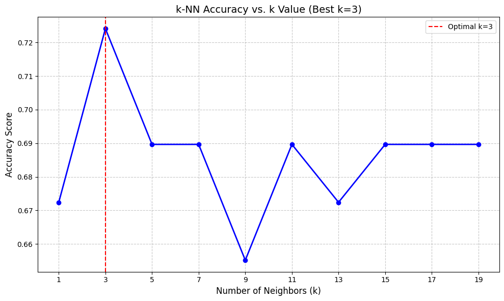

```python
import pandas as pd
import numpy as np
import matplotlib.pyplot as plt
import seaborn as sns
from sklearn.model_selection import train_test_split
from sklearn.neighbors import KNeighborsClassifier
from sklearn.metrics import accuracy_score, confusion_matrix, classification_report

# --- PART 1: LOAD DATA ---
# Ensure these files are in your directory
try:
    df_raw = pd.read_csv('/content/adjusted_noisy_knn_300.csv')
    df_cleaned = pd.read_csv('/content/cleaned_knn_data.csv')
except FileNotFoundError:
    print("Error: Please upload 'adjusted_noisy_knn_300.csv' and 'cleaned_knn_data.csv'")

# --- PART 2: BASELINE RUN (Raw Data) ---
# Strategy: Numeric columns only, Drop rows with Missing Values
print("\n--- RUNNING BASELINE MODEL ---")
df_naive = df_raw.select_dtypes(include=['number']).dropna()
X_base = df_naive.drop(columns=['Purchase_Likelihood'])
y_base = df_naive['Purchase_Likelihood']

# Split Data (80/20)
X_train_b, X_test_b, y_train_b, y_test_b = train_test_split(X_base, y_base, test_size=0.2, random_state=42)

# Train kNN (k=5)
knn_base = KNeighborsClassifier(n_neighbors=5)
knn_base.fit(X_train_b, y_train_b)
y_pred_b = knn_base.predict(X_test_b)

# Metrics
acc_base = accuracy_score(y_test_b, y_pred_b)
cm_base = confusion_matrix(y_test_b, y_pred_b)

# --- PART 3: OPTIMIZED RUN (Prepared Data) ---
# Strategy: Full dataset, Imputed, Scaled, One-Hot Encoded
print("--- RUNNING OPTIMIZED MODEL ---")
# Safety Check for any remaining NaNs
if df_cleaned.isnull().values.any():
    df_cleaned = df_cleaned.fillna(df_cleaned.median(numeric_only=True))

X_opt = df_cleaned.drop(columns=['Purchase_Likelihood'])
y_opt = df_cleaned['Purchase_Likelihood']

# Split Data (80/20)
X_train_o, X_test_o, y_train_o, y_test_o = train_test_split(X_opt, y_opt, test_size=0.2, random_state=42)

# Train kNN (k=5)
knn_opt = KNeighborsClassifier(n_neighbors=5)
knn_opt.fit(X_train_o, y_train_o)
y_pred_o = knn_opt.predict(X_test_o)

# Metrics
acc_opt = accuracy_score(y_test_o, y_pred_o)
cm_opt = confusion_matrix(y_test_o, y_pred_o)

# --- PART 4: GENERATE COMPARISON TABLE ---
results_df = pd.DataFrame({
    'Metric': ['Accuracy', 'Confusion Matrix (TN, FP, FN, TP)', 'Test Set Size'],
    'Baseline (Raw)': [
        f"{acc_base:.2%}",
        f"{cm_base.flatten()}",
        f"{len(y_test_b)}"
    ],
    'Optimized (Prepared)': [
        f"{acc_opt:.2%}",
        f"{cm_opt.flatten()}",
        f"{len(y_test_o)}"
    ]
})

print("\n=== PERFORMANCE COMPARISON TABLE ===")
print(results_df.to_string(index=False))

# --- PART 5: K-OPTIMIZATION LOOP (k=1 to 20) ---
print("\n--- RUNNING K-OPTIMIZATION ---")
k_values = [k for k in range(1, 21) if k % 2 != 0] # Odd numbers 1-19
accuracies = []

for k in k_values:
    knn_temp = KNeighborsClassifier(n_neighbors=k)
    knn_temp.fit(X_train_o, y_train_o)
    acc_temp = knn_temp.score(X_test_o, y_test_o)
    accuracies.append(acc_temp)

# Find Best k
best_idx = np.argmax(accuracies)
best_k = k_values[best_idx]
best_acc = accuracies[best_idx]

print(f"Optimal k found: {best_k} with Accuracy: {best_acc:.2%}")

# Plotting
plt.figure(figsize=(10, 6))
plt.plot(k_values, accuracies, marker='o', linestyle='-', color='blue', linewidth=2)
plt.title(f'k-NN Accuracy vs. k Value (Best k={best_k})', fontsize=14)
plt.xlabel('Number of Neighbors (k)', fontsize=12)
plt.ylabel('Accuracy Score', fontsize=12)
plt.xticks(k_values)
plt.grid(True, linestyle='--', alpha=0.7)
plt.axvline(x=best_k, color='red', linestyle='--', label=f'Optimal k={best_k}')
plt.legend()
plt.tight_layout()

# Save Plot
plt.savefig('k_optimization_plot.png')
print("Plot saved as 'k_optimization_plot.png'")
plt.show()
```